# Initial EDA Basic Outline

Abdulaziz Bokijonov

This is an outline for your Initial EDA. You can follow this outline, or you can modify it as you see fit. Do what works best for your project.

## Research Question

My research data is student alcohol consumption. This dataset has columns indicating school, sex, age, family size, parents cohabitation status, mothers and fathers education, travel time from home to school, and number of past classes failed and etc. for all cases, which are students. Using this data I want to find if there is any correlation between those variables and the alcohol consumption of students. Which factors influence the alcoholism among students the most, does alcohol influence the school work, do some combination of variables cause more alcoholism and does it change over time? Any other interesting trends and correlations will be addressed as well.

In addition to this data set, I picked one more about life expectancy. Cases are countries from 2000 till 2015 followed by data about life expectancy, alcohol, deaths and etc. Does alcohol effects mortality and exposure to Hepatitis B?

It is an interesting research, because as a college student I am eager to learn the insights of my own college life and what factors influence it and what are results I might expect from it. Also, from the second data set, I want to see how badly does alcohol affect life expectancy and overall health.

## Data Processing

#### Data Intake

Include R code and written explanation to import your **TWO** data sets.

```r
library(tidyverse)
library(dcData)
DataTable <- read.csv("student-alcohol-consumption.csv")
DataTableLife <- read.csv("Life Expectancy Data.csv")
head(DataTable)
```

|  | school | sex | age | address | famsize | Pstatus | Medu | Fedu | Mjob | Fjob | reason | guardian | traveltime | studytime | failures | schoolsup | famsup | paid | activities | nursery | higher | internet | romantic | famrel | freetime | goout | Dalc | Walc | health | … |
| --- | --- | --- | --- | --- | --- | --- | --- | --- | --- | --- | --- | --- | --- | --- | --- | --- | --- | --- | --- | --- | --- | --- | --- | --- | --- | --- | --- | --- | --- | --- |
| 1 | GP | F | 18 | U | GT3 | A | 4 | 4 | at_home | teacher | course | mother | 2 | 2 | 0 | yes | no | no | no | yes | yes | no | no | 4 | 3 | 4 | 1 | 1 | 3 | … |
| 2 | GP | F | 17 | U | GT3 | T | 1 | 1 | at_home | other | course | father | 1 | 2 | 0 | no | yes | no | no | no | yes | yes | no | 5 | 3 | 3 | 1 | 1 | 3 | … |
| 3 | GP | F | 15 | U | LE3 | T | 1 | 1 | at_home | other | other | mother | 1 | 2 | 3 | yes | no | yes | no | yes | yes | yes | no | 4 | 3 | 2 | 2 | 3 | 3 | … |
| 4 | GP | F | 15 | U | GT3 | T | 4 | 2 | health | services | home | mother | 1 | 3 | 0 | no | yes | yes | yes | yes | yes | yes | yes | 3 | 2 | 2 | 1 | 1 | 5 | … |
| 5 | GP | F | 16 | U | GT3 | T | 3 | 3 | other | other | home | father | 1 | 2 | 0 | no | yes | yes | no | yes | yes | no | no | 4 | 3 | 2 | 1 | 2 | 5 | … |
| 6 | GP | M | 16 | U | LE3 | T | 4 | 3 | services | other | reputation | mother | 1 | 2 | 0 | no | yes | yes | yes | yes | yes | yes | no | 5 | 4 | 2 | 1 | 2 | 5 | … |

```r
head(DataTableLife)
```

|  | Country | Year | Status | Life.expectancy | Adult.Mortality | infant.deaths | Alcohol | percentage.expenditure | Hepatitis.B | Measles | BMI | under.five.deaths | Polio | Total.expenditure | Diphtheria | HIV.AIDS | GDP | Population | thinness..1.19.years | thinness.5.9.years | Income.composition.of.resources | Schooling |
| --- | --- | --- | --- | --- | --- | --- | --- | --- | --- | --- | --- | --- | --- | --- | --- | --- | --- | --- | --- | --- | --- | --- |
| 1 | Afghanistan | 2015 | Developing | 65.0 | 263 | 62 | 0.01 | 71.279624 | 65 | 1154 | 19.1 | 83 | 6 | 8.16 | 65 | 0.1 | 584.25921 | 33736494 | 17.2 | 17.3 | 0.479 | 10.1 |
| 2 | Afghanistan | 2014 | Developing | 59.9 | 271 | 64 | 0.01 | 73.523582 | 62 | 492 | 18.6 | 86 | 58 | 8.18 | 62 | 0.1 | 612.69651 | 327582 | 17.5 | 17.5 | 0.476 | 10.0 |
| 3 | Afghanistan | 2013 | Developing | 59.9 | 268 | 66 | 0.01 | 73.219243 | 64 | 430 | 18.1 | 89 | 62 | 8.13 | 64 | 0.1 | 631.74498 | 31731688 | 17.7 | 17.7 | 0.470 | 9.9 |
| 4 | Afghanistan | 2012 | Developing | 59.5 | 272 | 69 | 0.01 | 78.184215 | 67 | 2787 | 17.6 | 93 | 67 | 8.52 | 67 | 0.1 | 669.95900 | 3696958 | 17.9 | 18.0 | 0.463 | 9.8 |
| 5 | Afghanistan | 2011 | Developing | 59.2 | 275 | 71 | 0.01 | 7.097109 | 68 | 3013 | 17.2 | 97 | 68 | 7.87 | 68 | 0.1 | 63.53723 | 2978599 | 18.2 | 18.2 | 0.454 | 9.5 |
| 6 | Afghanistan | 2010 | Developing | 58.8 | 279 | 74 | 0.01 | 79.679367 | 66 | 1989 | 16.7 | 102 | 66 | 9.20 | 66 | 0.1 | 553.32894 | 2883167 | 18.4 | 18.4 | 0.448 | 9.2 |

To use the data, I just downloaded the data csv files from Kaggle website and used read.csv function to import them into the r environment.

In the first dataset, the cases are student and here are the key variables:

school: The school the student attends (categorical: “GP” - Gabriel Pereira, “MS” - Mousinho da Silveira)

sex: The sex of the student (categorical: “F” - female, “M” - male)

age: The age of the student (quantitative: 15-22)

famsize: Family size (categorical: “GT3” - greater than 3, “LE3” - less than or equal to 3)

Pstatus: Parent’s cohabitation status (categorical: “T” - living together, “A” - living apart)

Medu: Mother’s education level (quantitative: 0-4, represents different levels of education)

Fedu: Father’s education level (quantitative: 0-4, represents different levels of education)

traveltime: Travel time from home to school (quantitative: 1-4, represents different levels of time)

failures: Number of past class failures (quantitative: 0-4)

Dalc: workday alcohol consumption (quantitative: from 1 - very low to 5 - very high)

Walc: weekend alcohol consumption (quantitative: from 1 - very low to 5 - very high)

health current health status (quantitative: from 1 - very bad to 5 - very good)

absences - number of school absences (quantitative: from 0 to 93)

Potential outliers of this data can be people who are acing both alcoholism and academics, because I suppose alcoholism would be negatively reflected on the academics

In the second data set, cases are countries from 2000 till 2015 followed by these key variables:

country (categorical),

year (quantitative),

status (categorical),

Life expectancy (quantitative),

Alcohol, (quantitative) recorded per capita (15+) consumption (in litres of pure alcohol)

Adult Mortality Rates of both sexes (quantitative) (probability of dying between 15 and 60 years per 1000 population)

The ourliers for this data set can be countries that don’t have high quality of life, thus more mortality rate not related to alcohol.

#### Data Wrangling

Include R code and written explanation for wangling your data (you can make multiple wrangled data sets).

```r
# Alcohol consumption and failed classes count
AlcoholFClasses <-
  DataTable %>%
  group_by(failures) %>%
  summarise(meanAlcWeekday = mean(Dalc),
            meanAlcWeekend = mean(Walc))
AlcoholFClasses
```

| failures | meanAlcWeekday | meanAlcWeekend |
| --- | --- | --- |
| 0 | 1.416667 | 2.205128 |
| 1 | 1.680000 | 2.500000 |
| 2 | 1.764706 | 2.647059 |
| 3 | 1.812500 | 2.937500 |

```r
# Alcohol consumption and age
AlcoholAge <-
  DataTable %>%
  group_by(age) %>%
  summarise(meanAlcWeekday = mean(Dalc),
            meanAlcWeekend = mean(Walc))
AlcoholAge
```

| age | meanAlcWeekday | meanAlcWeekend |
| --- | --- | --- |
| 15 | 1.353659 | 1.902439 |
| 16 | 1.432692 | 2.278846 |
| 17 | 1.520408 | 2.571429 |
| 18 | 1.548780 | 2.414634 |
| 19 | 1.458333 | 1.958333 |
| 20 | 2.000000 | 2.333333 |
| 21 | 3.000000 | 3.000000 |
| 22 | 5.000000 | 5.000000 |

```r
# Alcohol consumption by sex
AlcoholSex <-
  DataTable %>%
  group_by(sex) %>%
  summarise(meanAlcWeekday = mean(Dalc),
            meanAlcWeekend = mean(Walc))
AlcoholSex
```

| sex | meanAlcWeekday | meanAlcWeekend |
| --- | --- | --- |
| F | 1.254808 | 1.956731 |
| M | 1.732620 | 2.663102 |

```r
# Alcohol consumption and life expectancy with deaths
AlcoholLife <- DataTableLife %>%
  group_by(Alcohol) %>%
  filter(Status == "Developed") %>%
  summarise(exp = Life.expectancy, deaths = Adult.Mortality, year = Year)
AlcoholLife
```

| Alcohol | exp | deaths | year |
| --- | --- | --- | --- |
| 0.01 | 83.0 | 53 | 2014 |
| 0.01 | 75.6 | 137 | 2014 |
| 0.01 | 83.5 | 57 | 2014 |
| 0.01 | 74.4 | 156 | 2014 |
| 0.01 | 81.7 | 58 | 2014 |
| 0.01 | 74.8 | 135 | 2014 |
| 0.01 | 82.6 | 58 | 2014 |
| 1.43 | 79.3 | 73 | 2003 |
| 1.45 | 79.7 | 71 | 2004 |
| 1.49 | 82.0 | 69 | 2005 |

[output cut: 502 more lines]

```r
NA
```

This new wrangled data creates a table of the class failures as cases and mean alcohol consumption during weekday and during weekend, to see if there is a correlation.

The second wrangled data creates a table of ages as cases and mean alcohol consumption during the weekday and during the weekend.

The last wrangled data creates a table of alcohol consumption in developed countries (to exclude 3rd world countries that have low lie expectancy) with life expectancy and deaths among adults.

## Data Visualization

#### Plot 1

Include R code to make one data visualization (I would encourage you to use 3 or more variables). Include a brief written description of what your graph shows. Is this graph helpful in answering your research question? If it is helpful, will you need to add/modify anything in this graph in the final report?

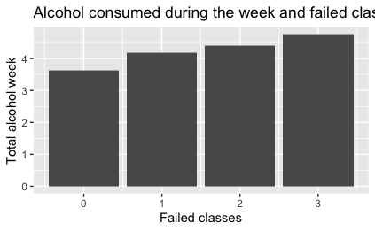

```r
AlcoholFClasses %>%
  ggplot(aes(x=failures,y=(meanAlcWeekday+meanAlcWeekend))) +
  geom_bar(stat='identity',position='stack', width=.9) +
  labs(y= "Total alcohol week", x = "Failed classes") +
  ggtitle("Alcohol consumed during the week and failed classes")
```

#### Plot 2

Include R code to make one data visualization (I would encourage you to use 3 or more variables). Include a brief written description of what your graph shows. Is this graph helpful in answering your research question? If it is helpful, will you need to add/modify anything in this graph in the final report?

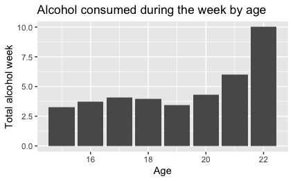

```r
AlcoholAge %>%
  ggplot(aes(x=age,y=(meanAlcWeekday+meanAlcWeekend))) +
  geom_bar(stat='identity',position='stack', width=.9) +
  labs(y= "Total alcohol week", x = "Age") +
  ggtitle("Alcohol consumed during the week by age")
```

In this graph we can see that people drink more when they get older, age 22 being the peak. It is a very usefull information, because it can give us further insights into the data and the knowtion that drinking increases by time among students. Next step is to add more variables to see what causes it or what it might be causing.